# R Training 2

# Exercise 5: Filter a signal

Remember to install or import any libraries we will be using:

```r
library(seewave)
library(tuneR)
library(varbvs)
```

First let’s filter an artificial signal. We’ll add two sinewaves together:

one with a frequency of 5 kHz and the other at 500 Hz. We’ve done this before, so no problem!

```r
freq1 = 5000;
freq2 = 500;
Fs = 20000;
intvl = 1/Fs;
secs = 2;
tim = seq(intvl, secs, intvl)
amp1 = 1;
amp2 = 1;
wave1 = sin(tim*2*pi*freq1) * amp1;
wave2 = sin(tim*2*pi*freq2) * amp2;
addwav = wave1 + wave2;
```

We’ll do a high-pass and a low-pass filter. We can have different frequencies for the high- and low-pass parts, but to start we’ll use the same frequency, 2500Hz.

```r
lowcut = 2500
highcut = 2500
```

These next steps make the filter. There are many types of filter – the one we are using is called a “Butterworth” filter. The only thing to change here is the order, **n** – which is the slope of the filter. Lower numbers have a broader slope, whereas higher numbers have a steeper slope.

We will be using the function:

bwfilter(wave, f, n = 1, from = NULL, to = NULL, bandpass = TRUE)

We can specify a few parameters: **wave** specifies our wave file, **f** is the sampling frequency, **n** is the order of the filter, **from** and**to** give the start and end frequencies, respectively. Don’t worry about **bandpass** right now.

```r
lowfilt = bwfilter(addwav, Fs, n = 5, from = NULL, to = 2500 )
highfilt = bwfilter(addwav, Fs, n = 5, from = 2500, to = NULL )
```

Now let’s plot the results.

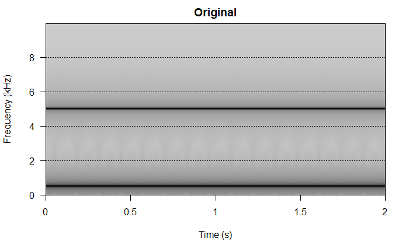

```r
spectro(addwav, Fs, wl = 512, palette = reverse.gray.colors.1, collevels = seq(-200, 0, 1), scale = FALSE, main = "Original")
```

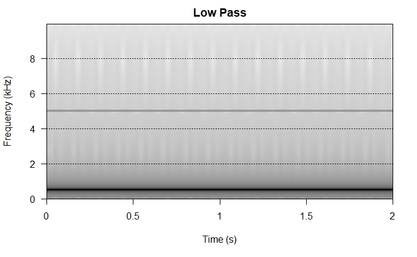

```r
spectro(lowfilt, Fs, wl = 512, palette = reverse.gray.colors.1, collevels = seq(-200, 0, 1), scale = FALSE, main = "Low Pass")
```

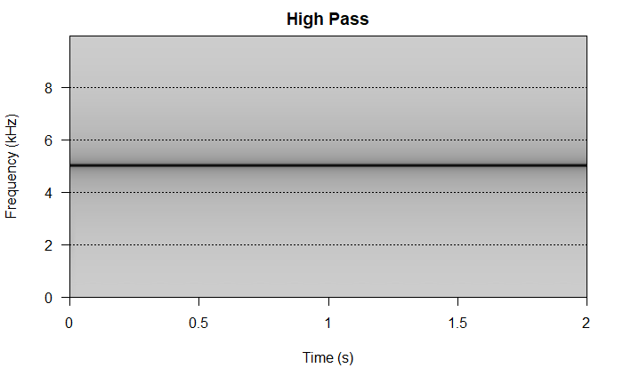

```r
spectro(highfilt, Fs, wl = 512, palette = reverse.gray.colors.1, collevels = seq(-200, 0, 1), scale = FALSE, main = "High Pass")
```

# Exercise 6: Filter a signal - noise

The first step is to make a noisy signal. Set the length, in seconds

```r
len = 1
```

Set the SampleRate, in Hz. and make a time series…

```r
Fs = 20000
tim = seq(1/Fs, len, 1/Fs)
```

Make the noise sequence using **randn**, a function from the package **varbvs**. This function selects semi-random numbers from a matrix with dimensions we will specify.  
The arguments are **m** and **n**. We want a 1 dimensional noisy sequence, hence the second dimension **n** is 1.

```r
noisy = randn(length(tim), 1)
```

This is great - we can plot this

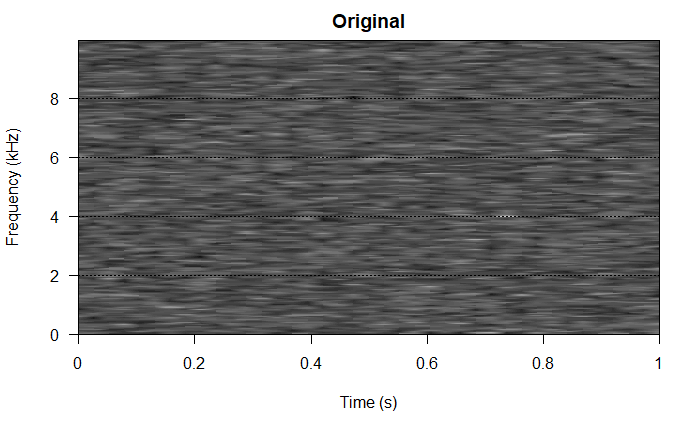

```r
spectro(noisy, Fs, wl = 512, palette = reverse.gray.colors.1, collevels = seq(-80, 0, 1), scale = FALSE, main = "Original")
```

Now we filter, as above, this time using differnt frequencies for our filters.

Our low pass filter will have a max frequency of 1500. Our high pass filter will have a minimum frequency of 2700.

```r
lowfilt_noise = bwfilter(noisy, Fs, n = 5, from = NULL, to = 1500 )
highfilt_noise = bwfilter(noisy, Fs, n = 5, from = 2700, to = NULL )
```

Now we can plot these as sonograms.

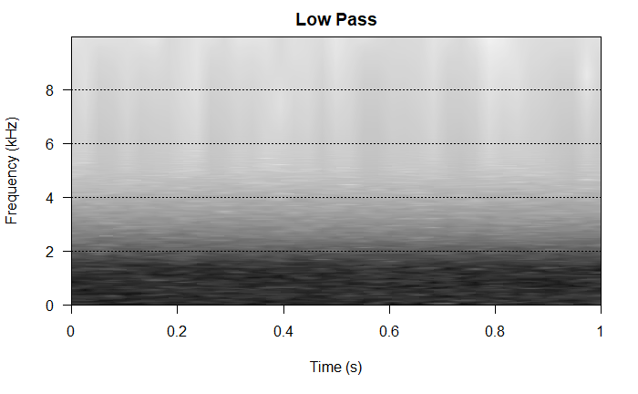

```r
spectro(lowfilt_noise, Fs, wl = 512, palette = reverse.gray.colors.1, collevels = seq(-200, 0, 1), scale = FALSE, main = "Low Pass")
```

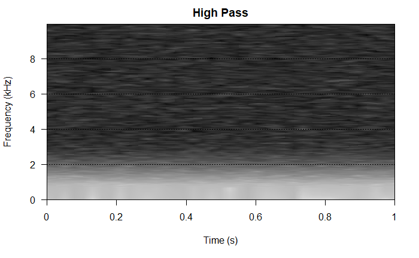

```r
spectro(highfilt_noise, Fs, wl = 512, palette = reverse.gray.colors.1, collevels = seq(-200, 0, 1), scale = FALSE, main = "High Pass")
```

### Exercise 6.1

Vary the ‘order’ of the filter between 1 and 9. What happens?

Can you make a bandpass signal, where you filter out signal below 1000 Hz and above 7700 Hz??

# Exercise 7: Reverse a signal

First we needs a signal – let’s use the zebra finch song

```r
zf_data = readWave('zfinch.wav')
```

Now we reverse it. We extract the relevant data from our wave file, **zf_data@left** and then reorder by specifying a sequence.

```r
zf_data_rev = zf_data@left[seq(to = 1, by = -1, length.out = length(zf_data@left))]
```

We can also halve the sample rate by increasing the **by =** parameter.

```r
zf_data_rev_half = zf_data@left[seq(to = 1, by = -2, length.out = length(zf_data@left)/2)]
```

Thats all there is to it!

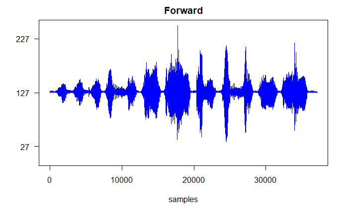

```r
plot(zf_data, xunit = "samples", main = "Forward", col = "Blue")
```

*Note: When ploting the modified data some parameters need to be manaully set*

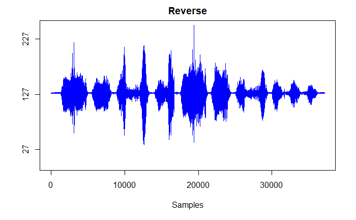

```r
plot(zf_data_rev, main = "Reverse", col = "Blue", type = "l", xlab = "Samples", ylab = "", ylim = c(0,250), yaxt = "none")
axis(2, seq(27, 227,100))
```

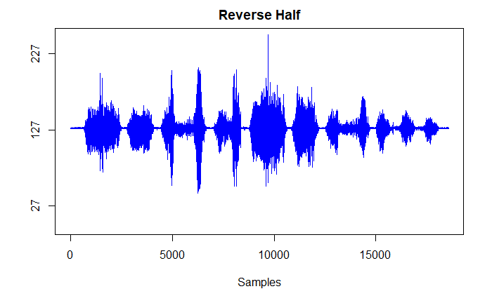

```r
plot(zf_data_rev_half, main = "Reverse Half", col = "Blue", type = "l", xlab = "Samples", ylab = "", ylim = c(0,250), yaxt = "none")
axis(2, seq(27, 227,100))
```

# Exercise 8: Finding data with the “Which” function

The **which()** function is a powerful tool which returns the indices of an object that fullfills a given logical statement. We can use this to extract portions of data that meet our parameters and then plot that data to highlight areas of interest

First let’s get a signal and plot it:

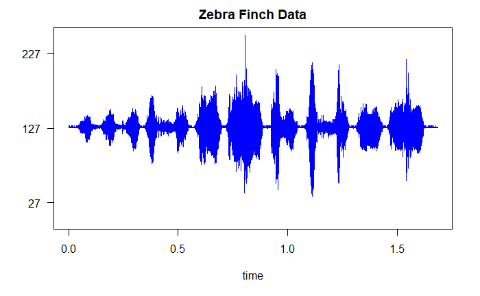

```r
plot(zf_data, main = "Zebra Finch Data", col = "Blue")
```

```r
zfFs = zf_data@samp.rate
tim = seq(1/zfFs, length(zf_data@left)/zfFs, 1/zfFs)
tmax = tim[length(tim)]
```

Perhaps we only want to examine the last syllable. We can use the **xlim** parameter in our plot to only view that syllable

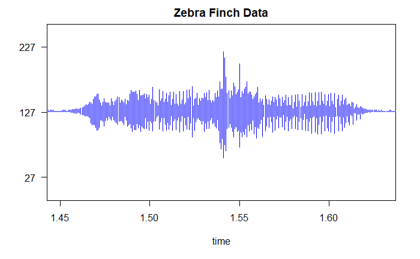

```r
plot(zf_data, main = "Zebra Finch Data", col = "Blue", xlim = c(1.45, 1.63))
```

This *only* plots the selected x range. What if we want to examine that last syllable *and* still plot the rest of the data?

To do this, we can use the **which** function to find the index of values that meet our criteria (in this case between 1.45 and 1.63). Then we plot that on top of our existing plot.

Lets use **which()** and store the result in variable **pp**:

```r
pp = which(tim >= 1.45 & tim <= 1.63)
```

Now that we’ve found the *positions* of our samples, we can graph by telling R to plot **tim[pp]** and **zf_data@left[pp]**.

In order for our suplot to lineup correctly, we need to create a variable **tmax** to serve as our manual upper x limit.

```r
tmax = tim[length(tim)]
```

Now we can go ahead an plot using **par(new = TRUE)** to plot on the same graph.

*There are a lot of parameters here that can affect the graph. Go ahead and play around with them to see what each does and why they are used.*

```r
plot(tim, zf_data@left, main = "Zebra Finch Data", col = "Blue", type = "l", xlab = "Time" , ylab = "", yaxt = "none", ylim = c(0,250))
axis(2, seq(27, 227,100))
```

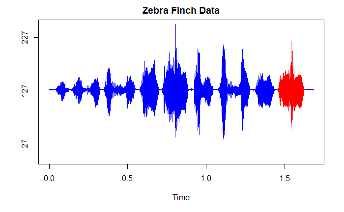

```r
par(new = TRUE)
plot(tim[pp], zf_data@left[pp], type = "l", col = "Red", xlim = c(0, tmax), xlab = "", ylab = "", yaxt = "none", ylim = c(0,250), xaxt = "n", yaxt = "n")
```

We can do the same thing for the y-axis. Lets select all of the values about *137*.

```r
ppy = which(zf_data@left > 137)
plot(tim, zf_data@left, main = "Zebra Finch Data", col = "Blue", type = "l", xlab = "Time" , ylab = "", yaxt = "none", ylim = c(0,250))
axis(2, seq(27, 227,100))
```

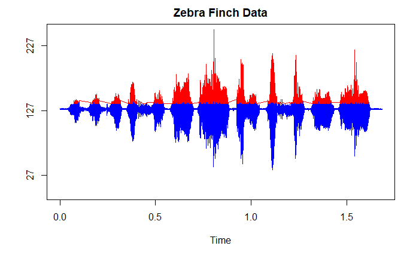

```r
par(new = TRUE)
plot(tim[ppy], zf_data@left[ppy], type = "l", col = "Red", xlim = c(0, tmax), xlab = "", ylab = "", yaxt = "none", ylim = c(0,250), xaxt = "n", yaxt = "n")
```